# Substantive and statistical hypotheses in data-oriented philology and linguistics

Roland Schäfer, Friedrich-Schiller-Universität Jena

2024-08-20

# 1 How to find things out

## 1.1 “It’s better to pursue your own projects!”

## 1.2 Hypotheses, falsificationism and severe testing

## 1.3 The difference between substantive, particular, and statistical hypotheses

# 2 Data and inferences in Walkden et al. (2023)

## 2.1 Main hypotheses and purpose

## 2.2 Study 1: Agreement

### 2.2.1 What was reported

Study 1 deals with the loss of inflectional marking in Middle English. It is interpreted as a loss of redundancy that plural marking is lost on attributive adjectives and determiners partially to a different degree and under the influence of Scandianavian language contact from the eighth until the eleventh century. The study looks at determiners (referred to as *quantifiers* throughout, although not all determiners are quantificational) and monosyllabic adjectives in 47 texts totalling 4,366 data points (called *tokens* on p. 551).

Based on a plot overlaying texts as dots on a map of England (their Figure 1), it is argued some texts show stronger loss of inflecion on the determiner than on the adjectice. Walkden et al. (2023, 552) claim that “this difference does not depend on the date of composition of the manuscript, but rather on the dialectal region. The majority of texts which show a difference between quantifiers and adjectives come from areas where Scandinavian contact was intense.” The parameters of a linear model with “with the difference in agreement between adjectives and quantifiers as our dependent variable and region as independent variable” are estimated, and with the South as the reference category (because it had the least amount of Scandinavian language contact), the authors find a “significant” effect for North and the East Midlands but not the West Midlands.

### 2.2.2 Alternative models

### 2.2.3 Interpretation of the model

## 2.3 Study 2: Null subjects

### 2.3.1 What was reported

The authors want to model the influence of orality, time, and region (Spain versus Latin American countries) on the tendency to use overt subjects in Spanish despite the overall very strong tendency towards subject drop in Spanish. Orality is measured as the ORSCORE, which appears to be the aggregate relative frequency of certain grammatical features in the respective texts. It is thus based on a derived construct and not on direct observations. Given the fact that it is composed of proportions (relative frequencies) the warnings raised in the previous section apply here as well. Here is the report of the model fit from the paper, where `sub_POS` is 1 for an observation with an overt subject, `ORScoreZ` is the z-transformed orality score, `YearZ` is the z-transformed year the respective document was dated at, and `Macro_Region` is Spain or Non-Spain. The random effect `docID` has 37 levels for 37 documents.

```
## Generalized linear mixed model fit by maximum likelihood (Laplace
##   Approximation) [glmerMod]
##  Family: binomial  ( logit )
## Formula: sub_POS ~ ORScoreZ * YearZ + Macro_Region + (1 | docID)
##    Data: SubjectData
##
##      AIC      BIC   logLik deviance df.resid
##   2548.2   2585.6  -1268.1   2536.2     3767
##
## Scaled residuals:
##     Min      1Q  Median      3Q     Max
## -0.5568 -0.4031 -0.2986 -0.2208  7.2692
##
## Random effects:
##  Groups Name        Variance Std.Dev.
##  docID  (Intercept) 0.3119   0.5585
## Number of obs: 3773, groups:  docID, 37
##
## Fixed effects:
##                       Estimate Std. Error z value Pr(>|z|)
## (Intercept)           -2.54816    0.27581  -9.239  < 2e-16 ***
## ORScoreZ               1.02970    0.26926   3.824 0.000131 ***
## YearZ                  0.05029    0.15366   0.327 0.743470
## Macro_RegionNon-Spain  0.62880    0.32012   1.964 0.049499 *
## ORScoreZ:YearZ        -0.43702    0.20640  -2.117 0.034233 *
## ---
## Signif. codes:  0 '***' 0.001 '**' 0.01 '*' 0.05 '.' 0.1 ' ' 1
```

### 2.3.2 Alternative models

We begin by comparing the *Paper* model (the one reported in the original paper) to a *Null* model that only has a fixed intercept and a random intercept for *document*. In other words, we allow the intercept to vary between groups of data points defined by the texts they occur in, and no other explanatory variables are included. We use the `performance` package for a quick model comparison.

```
## Generalized linear mixed model fit by maximum likelihood (Laplace
##   Approximation) [glmerMod]
##  Family: binomial  ( logit )
## Formula: sub_POS ~ 1 + (1 | docID)
##    Data: SubjectData
##
##      AIC      BIC   logLik deviance df.resid
##   2562.6   2575.1  -1279.3   2558.6     3771
##
## Scaled residuals:
##     Min      1Q  Median      3Q     Max
## -0.5496 -0.4047 -0.3101 -0.2118  6.7085
##
## Random effects:
##  Groups Name        Variance Std.Dev.
##  docID  (Intercept) 0.7395   0.8599
## Number of obs: 3773, groups:  docID, 37
##
## Fixed effects:
##             Estimate Std. Error z value Pr(>|z|)
## (Intercept)  -2.4566     0.1665  -14.76   <2e-16 ***
## ---
## Signif. codes:  0 '***' 0.001 '**' 0.01 '*' 0.05 '.' 0.1 ' ' 1
```

```
## # Comparison of Model Performance Indices
##
## Name              |      AIC | R2 (cond.) | R2 (marg.)
## ------------------------------------------------------
## SubjectNullModel  | 2562.619 |      0.184 |      0.000
## SubjectPaperModel | 2548.202 |      0.206 |      0.131
```

The AIC of the Paper model is slighlty lower. The marginal R² of the Null model is of course 0, as there are no first-level fixed effects, but even the conditional R² of the Paper model is minimally higher than that of the Null model. All in all, it does not appear even from this simple evaluation as if the orality score, the macroregion, and the date of the document explain much of the variance in the data.

```
## Generalized linear mixed model fit by maximum likelihood (Laplace
##   Approximation) [glmerMod]
##  Family: binomial  ( logit )
## Formula: sub_POS ~ Country + Genre + (1 | docID)
##    Data: SubjectData
##
##      AIC      BIC   logLik deviance df.resid
##   2566.9   2616.8  -1275.5   2550.9     3765
##
## Scaled residuals:
##     Min      1Q  Median      3Q     Max
## -0.5942 -0.4059 -0.3074 -0.1994  6.6900
##
## Random effects:
##  Groups Name        Variance Std.Dev.
##  docID  (Intercept) 0.5604   0.7486
## Number of obs: 3773, groups:  docID, 37
##
## Fixed effects:
##                           Estimate Std. Error z value Pr(>|z|)
## (Intercept)                -2.7856     0.3659  -7.613 2.67e-14 ***
## CountryBolivia              0.3218     0.5017   0.642   0.5212
## CountryColombia            -0.1248     0.4462  -0.280   0.7797
## CountryDominican Republic   0.0191     0.4598   0.042   0.9669
## CountryPanamá               0.2811     0.4739   0.593   0.5531
## GenreLIT                    0.2702     0.3134   0.862   0.3885
## GenreSUPP                   1.3102     0.5187   2.526   0.0115 *
## ---
## Signif. codes:  0 '***' 0.001 '**' 0.01 '*' 0.05 '.' 0.1 ' ' 1
```

```
## # Comparison of Model Performance Indices
##
## Name                     |      AIC | R2 (cond.) | R2 (marg.)
## -------------------------------------------------------------
## SubjectCountryGenreModel | 2566.931 |      0.185 |      0.047
## SubjectPaperModel        | 2548.202 |      0.206 |      0.131
```

We see that the Country-Genre model is also slightly worse than the Paper model. It is unclear, however, why the paper claims that the country regressor was impossible to add for technical reasons. The estimator has no trouble estimating the coefficients, they just don’t reach the nominal significance level of 0.05.

We proceed to estimating the parameters of a more complex model. This Full-Country model is the Paper model including orality and year as regressors but with country instead of macroregion and additionally genre as fixed effects.

```
## Generalized linear mixed model fit by maximum likelihood (Laplace
##   Approximation) [glmerMod]
##  Family: binomial  ( logit )
## Formula: sub_POS ~ ORScoreZ * YearZ + Country + Genre + (1 | docID)
##    Data: SubjectData
##
##      AIC      BIC   logLik deviance df.resid
##   2555.6   2624.2  -1266.8   2533.6     3762
##
## Scaled residuals:
##     Min      1Q  Median      3Q     Max
## -0.5581 -0.4068 -0.2995 -0.2225  8.0898
##
## Random effects:
##  Groups Name        Variance Std.Dev.
##  docID  (Intercept) 0.2878   0.5365
## Number of obs: 3773, groups:  docID, 37
##
## Fixed effects:
##                           Estimate Std. Error z value Pr(>|z|)
## (Intercept)               -2.61848    0.30656  -8.541  < 2e-16 ***
## ORScoreZ                   1.12320    0.29921   3.754 0.000174 ***
## YearZ                     -0.05799    0.17484  -0.332 0.740130
## CountryBolivia             0.95893    0.46686   2.054 0.039975 *
## CountryColombia            0.68220    0.42290   1.613 0.106713
## CountryDominican Republic  0.39182    0.39506   0.992 0.321298
## CountryPanamá              0.51228    0.39301   1.303 0.192414
## GenreLIT                   0.19721    0.25358   0.778 0.436739
## GenreSUPP                  0.27640    0.49749   0.556 0.578499
## ORScoreZ:YearZ            -0.57740    0.23560  -2.451 0.014254 *
## ---
## Signif. codes:  0 '***' 0.001 '**' 0.01 '*' 0.05 '.' 0.1 ' ' 1
```

```
## # Comparison of Model Performance Indices
##
## Name                    |      AIC | R2 (cond.) | R2 (marg.)
## ------------------------------------------------------------
## SubjectFullCountryModel | 2555.599 |      0.210 |      0.141
## SubjectPaperModel       | 2548.202 |      0.206 |      0.131
```

The Full-Country model performs slightly better than the Paper model in terms of the R². It should, however, have become clear by now that the slightly varying conditional R² coefficients are merely an artefact due to the shifting marginal R² coefficients. Additionally, we observe that country has only one level (Bolivia) that is sufficiently distinct from the intercept value (Spain) to reach the nominal significance level. Concluding from the data presented in the paper that “overtness [is favoured] in every country but Spain” is thus not warranted, even under an NHST umbrella. If we drop genre, the picture changes again with the Full-No-Genre model.

```
## Generalized linear mixed model fit by maximum likelihood (Laplace
##   Approximation) [glmerMod]
##  Family: binomial  ( logit )
## Formula: sub_POS ~ ORScoreZ * YearZ + Country + (1 | docID)
##    Data: SubjectData
##
##      AIC      BIC   logLik deviance df.resid
##   2552.3   2608.4  -1267.1   2534.3     3764
##
## Scaled residuals:
##     Min      1Q  Median      3Q     Max
## -0.5577 -0.4049 -0.2989 -0.2155  7.9242
##
## Random effects:
##  Groups Name        Variance Std.Dev.
##  docID  (Intercept) 0.2985   0.5463
## Number of obs: 3773, groups:  docID, 37
##
## Fixed effects:
##                           Estimate Std. Error z value Pr(>|z|)
## (Intercept)               -2.51844    0.27207  -9.257   <2e-16 ***
## ORScoreZ                   1.15019    0.29565   3.890   0.0001 ***
## YearZ                     -0.03955    0.17139  -0.231   0.8175
## CountryBolivia             0.98618    0.46013   2.143   0.0321 *
## CountryColombia            0.76079    0.37712   2.017   0.0437 *
## CountryDominican Republic  0.40395    0.39636   1.019   0.3081
## CountryPanamá              0.53244    0.39171   1.359   0.1741
## ORScoreZ:YearZ            -0.56154    0.23591  -2.380   0.0173 *
## ---
## Signif. codes:  0 '***' 0.001 '**' 0.01 '*' 0.05 '.' 0.1 ' ' 1
```

```
## # Comparison of Model Performance Indices
##
## Name                    |      AIC | R2 (cond.) | R2 (marg.)
## ------------------------------------------------------------
## SubjectFullNoGenreModel | 2552.271 |      0.211 |      0.139
## SubjectPaperModel       | 2548.202 |      0.206 |      0.131
```

We see that model specification is not an exact art. Dropping genre as a regressor leads to Columbia also reaching the nominal significance level. Using NHST logic it is now Spain, Dominican Republic, and Panamá against Bolivia and Columbia. Regarding the R², the various model specifications don’t really seem to change much. In the next section, we show why.

### 2.3.3 Interpretation of the models

A (Generalised) Linear (Mixed) Model can be used to make predictions. In the case of Binomial models, it can estimate the probability with which the event (in this case overt realisation of a subject pronoun) occurs. If it estimates a probability greater than 0.5 for some combination of regressors, it is the most successful strategy to predict the occurrence of the event—if the model is correct. If it estimates a probability lower than 0.5, one should bet against the event and predict its non-occurrence. Now, we first check in tabular form what binary predictions the model makes on the 3,773 observations it was estimated on. Note that it should perform particularly well on those data because we use the model to predict the values it was estimated on. New data would always be harder to predict correctly for any statistical or machine-learning model.

```
##
## Pronoun
##    3773
```

Oddly, the model predicts that there should never be an overt subject. This is due to the obviously uninformative regressors and the high base rate. The base rate is the most frequent outcome (in this case, no overt subject), which occurs in 88.55% of all cases.

```
## [1] 0.8855023
```

```
##
##  NULL OVERT
##  3341   432
```

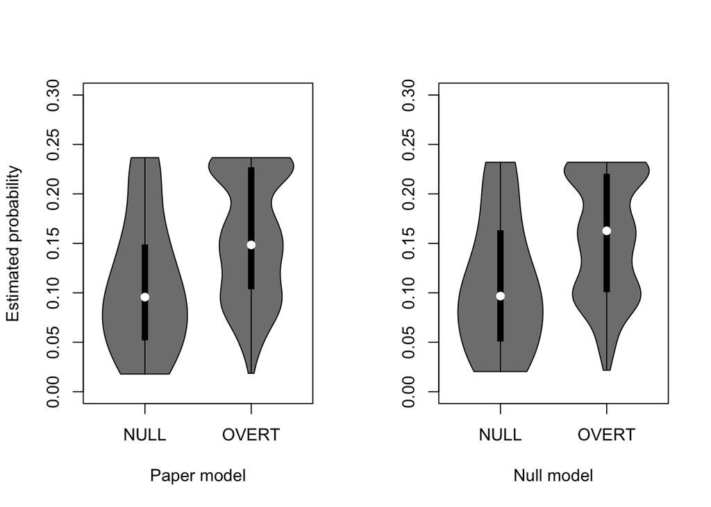

Even for the cases with overt subjects in the observed data, the model estimates a maximum probability of under 0.25. Most strikingly, the Paper model appears to estimate almost exactly the same probabilities as the null model. In other words, orality, time, and country (or macroregion) are irrelevant. Reaching the sigificance level is mostly just an effect of the relatively simple model structure, minute differences correlated with the regressors, and the relatively large sample size. Alls points of criticism against NHST apply.

Finally, we plot the probabilities estimated by the Paper model against the null model.

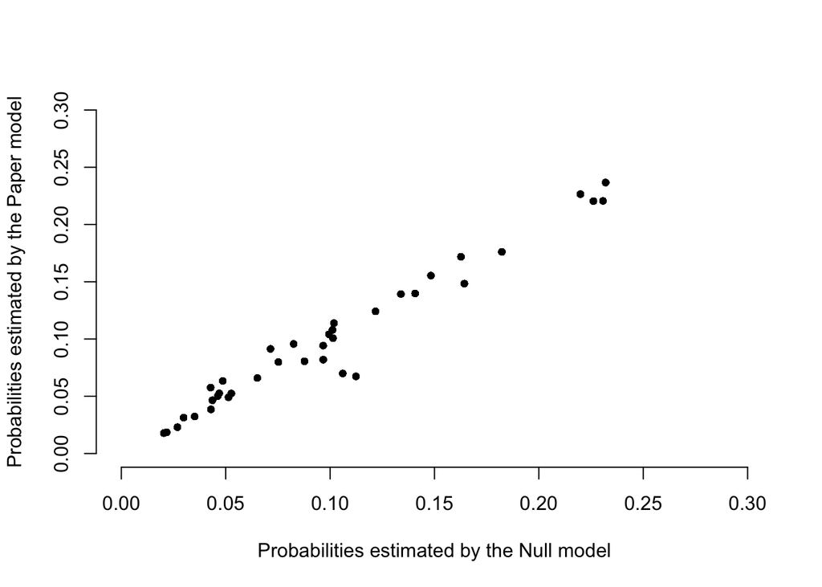

The plot show which probability the two models estimate for each of the 3,773 observed data points, each data point being plotted as a dot. If the two models made exactly the same estimates, there should be a straight line. We see dots virtually along a straight line with negligeable deviations. The models contain virtually the same information, and the mean absolute difference between the predictions by the two models is 0.0069, the maximal difference for a data point is 0.045.

## 2.4 What was actually found out

# 3 Putting data to good use

# References

Walkden, George, Gemma Hunter McCarley, Raquel Montero, Molly Rolf, Sarah Einhaus, and Henri Kauhanen. 2023. “Sociolinguistic Typology Meets Historical Corpus Linguistics.” *Transactions of the Philological Society* 121 (3): 546–67. https://doi.org/10.1111/1467-968X.12275.